# Evanston Hypothesis Testing

Adi Tyagi

8/17/2020

# Loading data and libraries

```r
library(tidyverse)
```

```r
library(ggplot2)

#test hypotheses on evanston only data
fa_pm_evanston = read_csv("../Data/Modelling Data/fa_pm_evanston-model.csv")
fa_pm_evanston %>% head()
```

```
## # A tibble: 6 x 33
##      X1 Tract  fips state total_population food_insecurity~
##   <dbl> <chr> <dbl> <chr>            <dbl>            <dbl>
## 1     0 Cens~ 17031 IL                5255            0.117
## 2     1 Cens~ 17031 IL                3732            0.049
## 3     2 Cens~ 17031 IL                4175            0.036
## 4     3 Cens~ 17031 IL                4153            0.045
## 5     4 Cens~ 17031 IL                3293            0.048
## 6     5 Cens~ 17031 IL                4823            0.165
## # ... with 27 more variables: food_insecurity_num_2018 <dbl>,
## #   food_insecurity_rate_2020 <dbl>, food_insecurity_num_2020 <dbl>,
## #   food_insecurity_num_change_2020 <dbl>, unemployment_change <dbl>,
## #   local_census_tract <dbl>, avg_household_size <dbl>,
## #   avg_travel_time_to_work <dbl>, computer_access <dbl>,
## #   life_expectancy <dbl>, median_age <dbl>,
## #   median_home_loan_amount <dbl>, median_home_value <dbl>,
## #   median_household_income <dbl>, median_leverage_ratio <dbl>,
## #   num_jobs <dbl>, num_housing_units <dbl>,
## #   proportion_bachelors_degree <dbl>, proportion_disabled <dbl>,
## #   proportion_hispanic <dbl>, prop_men <dbl>, prop_nonwhite <dbl>,
## #   prop_nonenglish_speaking <dbl>, prop_families_poverty <dbl>,
## #   prop_students_in_public_school <dbl>,
## #   social_vulnerability_index <dbl>, thiel_racial_segregation_index <dbl>
```

# Splitting the data

The top 5 most food insecure tracts are separate from the bottom 5 least food insecure tracts. This allocation is made based on 2018_food_insecurity_num.

```r
#top 5 tracts
top_n = fa_pm_evanston %>% arrange(desc(food_insecurity_num_2018))%>% head(5)
print(paste("Most food insecure tracts:",  top_n$local_census_tract))
```

```
## [1] "Most food insecure tracts: 809200" "Most food insecure tracts: 808702"
## [3] "Most food insecure tracts: 809400" "Most food insecure tracts: 810200"
## [5] "Most food insecure tracts: 809300"
```

```r
#bottom 5 tracts
bottom_n = fa_pm_evanston %>% arrange(desc(food_insecurity_num_2018)) %>% tail(5)

print(paste("Least food insecure tracts: " ,bottom_n$local_census_tract))
```

```
## [1] "Least food insecure tracts:  810302"
## [2] "Least food insecure tracts:  808800"
## [3] "Least food insecure tracts:  809100"
## [4] "Least food insecure tracts:  809900"
## [5] "Least food insecure tracts:  808900"
```

# Distribution of number of food insecure persons in 2018

There are some tracts with immense food insecurity (800 persons); while others have ~200 food insecure persons.

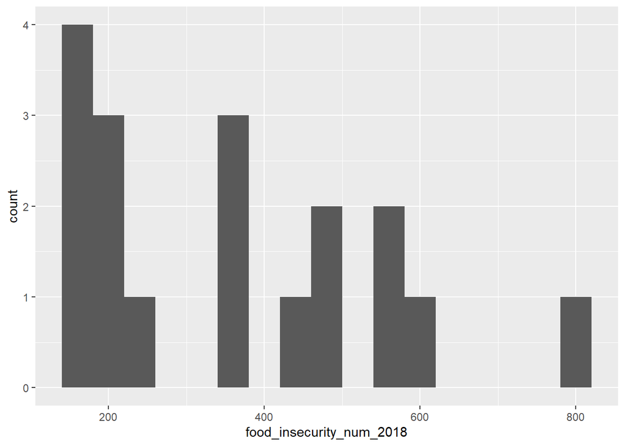

# Exploring differences in explanatory variables

## A simple analysis of difference

```r
var_list = c( 'median_household_income',
'median_age', 'social_vulnerability_index',
'median_home_loan_amount', 'median_home_value', 'prop_nonwhite',
'prop_nonenglish_speaking', 'proportion_hispanic',
'thiel_racial_segregation_index', 'proportion_bachelors_degree',
'computer_access', 'prop_families_poverty', 'num_jobs',
'num_housing_units', 'life_expectancy', 'avg_travel_time_to_work',
'prop_students_in_public_school', 'median_leverage_ratio',
'proportion_disabled', 'avg_household_size', 'prop_men')

for (var in var_list) {
  print(var)
  top_n_mean = mean(top_n[[var]])
  bottom_n_mean = mean(bottom_n[[var]])
  diff = top_n_mean - bottom_n_mean
  print(paste("top_n_mean:", top_n_mean))
  print(paste("bottom_n_mean:", bottom_n_mean))
  print(paste("diff:", top_n_mean - bottom_n_mean))
  print("------")
}
```

```
## [1] "median_household_income"
## [1] "top_n_mean: 53524.4"
## [1] "bottom_n_mean: 116378.6"
## [1] "diff: -62854.2"
## [1] "------"
## [1] "median_age"
## [1] "top_n_mean: 29"
## [1] "bottom_n_mean: 43"
## [1] "diff: -14"
## [1] "------"
## [1] "social_vulnerability_index"
## [1] "top_n_mean: 0.568"
## [1] "bottom_n_mean: 0.216"
## [1] "diff: 0.352"
## [1] "------"
```

[output cut: 90 more lines]

## Hypothesis testing

For each variable we will do a two-sided first. Then, if appropriate, we wil do a one-sided test. We will use a significance level of 10%. In some cases, we will use a significance level of 15%.

### median household income

Let’s begin with median_household_income

```r
t.test(top_n$median_household_income,bottom_n$median_household_income,
       alternative = "less")
```

```
##
##  Welch Two Sample t-test
##
## data:  top_n$median_household_income and bottom_n$median_household_income
## t = -4.951, df = 5.7754, p-value = 0.001434
## alternative hypothesis: true difference in means is less than 0
## 95 percent confidence interval:
##       -Inf -38012.29
## sample estimates:
## mean of x mean of y
##   53524.4  116378.6
```

Higher food insecurity tracts do indeed have a lower household income than do lower food insecurity tracts.

### median age

Let’s now do median age.

```r
t.test(top_n$median_age, bottom_n$median_age, alternative = "less")
```

```
##
##  Welch Two Sample t-test
##
## data:  top_n$median_age and bottom_n$median_age
## t = -4.4052, df = 4.9634, p-value = 0.003554
## alternative hypothesis: true difference in means is less than 0
## 95 percent confidence interval:
##       -Inf -7.585626
## sample estimates:
## mean of x mean of y
##        29        43
```

Higher food insecurity tracts have a lower age.

### social vulnerability index

```r
t.test(top_n$social_vulnerability_index, bottom_n$social_vulnerability_index, alternative = 'greater')
```

```
##
##  Welch Two Sample t-test
##
## data:  top_n$social_vulnerability_index and bottom_n$social_vulnerability_index
## t = 3.0095, df = 5.9507, p-value = 0.01198
## alternative hypothesis: true difference in means is greater than 0
## 95 percent confidence interval:
##  0.1243849       Inf
## sample estimates:
## mean of x mean of y
##     0.568     0.216
```

Food insecure tracts are more socially vulnerable.

### median home loan amount

```r
t.test(top_n$median_home_loan_amount, bottom_n$median_home_loan_amount, alternative = 'less')
```

```
##
##  Welch Two Sample t-test
##
## data:  top_n$median_home_loan_amount and bottom_n$median_home_loan_amount
## t = -2.8227, df = 7.5787, p-value = 0.01183
## alternative hypothesis: true difference in means is less than 0
## 95 percent confidence interval:
##       -Inf -47100.35
## sample estimates:
## mean of x mean of y
##    230000    370000
```

Food insecure tracts have a lower median home loan amount.

### median home value

```r
t.test(top_n$median_home_value, bottom_n$median_home_value, alternative = 'less')
```

```
##
##  Welch Two Sample t-test
##
## data:  top_n$median_home_value and bottom_n$median_home_value
## t = -2.2843, df = 7.6533, p-value = 0.02658
## alternative hypothesis: true difference in means is less than 0
## 95 percent confidence interval:
##    -Inf -37827
## sample estimates:
## mean of x mean of y
##    310240    519080
```

Food insecure tracts have lower median home value.

### prop nonwhite

```r
t.test(top_n$prop_nonwhite, bottom_n$prop_nonwhite, alternative = 'greater')
```

```
##
##  Welch Two Sample t-test
##
## data:  top_n$prop_nonwhite and bottom_n$prop_nonwhite
## t = 2.553, df = 7.4204, p-value = 0.01807
## alternative hypothesis: true difference in means is greater than 0
## 95 percent confidence interval:
##  6.439412      Inf
## sample estimates:
## mean of x mean of y
##    44.120    19.744
```

Food insecure tracts are more nonwhite in general.

### prop nonenglish speaking

```r
t.test(top_n$prop_nonenglish_speaking, bottom_n$prop_nonenglish_speaking, alternative = 'greater')
```

```
##
##  Welch Two Sample t-test
##
## data:  top_n$prop_nonenglish_speaking and bottom_n$prop_nonenglish_speaking
## t = 2.1423, df = 6.1547, p-value = 0.03738
## alternative hypothesis: true difference in means is greater than 0
## 95 percent confidence interval:
##  0.4097716       Inf
## sample estimates:
## mean of x mean of y
##     8.672     4.448
```

Food insecure tracts have a greater non english speaking proportion.

```r
t.test(top_n$proportion_hispanic, bottom_n$proportion_hispanic, alternative = 'greater')
```

```
##
##  Welch Two Sample t-test
##
## data:  top_n$proportion_hispanic and bottom_n$proportion_hispanic
## t = 2.3122, df = 5.0284, p-value = 0.03421
## alternative hypothesis: true difference in means is greater than 0
## 95 percent confidence interval:
##  1.129845      Inf
## sample estimates:
## mean of x mean of y
##    14.962     6.244
```

Food insecure tracts have a higher hispanic population.

### thiel racial segregation

```r
t.test(top_n$thiel_racial_segregation_index, bottom_n$thiel_racial_segregation_index, alternative = 'less')
```

```
##
##  Welch Two Sample t-test
##
## data:  top_n$thiel_racial_segregation_index and bottom_n$thiel_racial_segregation_index
## t = -2.112, df = 6.7175, p-value = 0.03712
## alternative hypothesis: true difference in means is less than 0
## 95 percent confidence interval:
##          -Inf -0.007583408
## sample estimates:
## mean of x mean of y
##     0.150     0.228
```

Food insecure tracts are less racial segregated.

### proportion bachelor’s degree

```r
t.test(top_n$proportion_bachelors_degree, bottom_n$proportion_bachelors_degree, alternative = 'less')
```

```
##
##  Welch Two Sample t-test
##
## data:  top_n$proportion_bachelors_degree and bottom_n$proportion_bachelors_degree
## t = -1.5736, df = 4.7631, p-value = 0.08963
## alternative hypothesis: true difference in means is less than 0
## 95 percent confidence interval:
##      -Inf 1.797072
## sample estimates:
## mean of x mean of y
##    25.318    31.416
```

Food insecure tracts have lower proportions with bachelor’s degree.

### computer access

```r
t.test(top_n$computer_access, bottom_n$computer_access, alternative = 'less')
```

```
##
##  Welch Two Sample t-test
##
## data:  top_n$computer_access and bottom_n$computer_access
## t = -1.8794, df = 7.4429, p-value = 0.04988
## alternative hypothesis: true difference in means is less than 0
## 95 percent confidence interval:
##         -Inf -0.00458601
## sample estimates:
## mean of x mean of y
##    90.522    95.806
```

Food insecure tracts have lower computer access.

### prop families poverty

```r
t.test(top_n$prop_families_poverty, bottom_n$prop_families_poverty, alternative = 'greater')
```

```
##
##  Welch Two Sample t-test
##
## data:  top_n$prop_families_poverty and bottom_n$prop_families_poverty
## t = 0.89435, df = 4.4123, p-value = 0.2086
## alternative hypothesis: true difference in means is greater than 0
## 95 percent confidence interval:
##  -4.465309       Inf
## sample estimates:
## mean of x mean of y
##     6.388     3.008
```

Food secure tracts are similar to food insecure tracts when it comes to prop families in poverty.

### num jobs

```r
t.test(top_n$num_jobs, bottom_n$num_jobs, alternative = 'greater')
```

```
##
##  Welch Two Sample t-test
##
## data:  top_n$num_jobs and bottom_n$num_jobs
## t = 1.2263, df = 6.0963, p-value = 0.1327
## alternative hypothesis: true difference in means is greater than 0
## 95 percent confidence interval:
##  -2242.723       Inf
## sample estimates:
## mean of x mean of y
##    5954.0    2088.2
```

We could say that food insecure tracts have more jobs located within them than food secure tracts.

### num housing units

```r
t.test(top_n$num_housing_units, bottom_n$num_housing_units, alternative = 'greater')
```

```
##
##  Welch Two Sample t-test
##
## data:  top_n$num_housing_units and bottom_n$num_housing_units
## t = 1.1102, df = 4.2088, p-value = 0.1631
## alternative hypothesis: true difference in means is greater than 0
## 95 percent confidence interval:
##  -496.8302       Inf
## sample estimates:
## mean of x mean of y
##    2060.8    1504.6
```

Food insecure tracts are similar to food secure tracts when it comes to housing units.

### life expectancy

```r
t.test(top_n$life_expectancy, bottom_n$life_expectancy, alternative = 'less')
```

```
##
##  Welch Two Sample t-test
##
## data:  top_n$life_expectancy and bottom_n$life_expectancy
## t = -1.1266, df = 7.754, p-value = 0.1468
## alternative hypothesis: true difference in means is less than 0
## 95 percent confidence interval:
##      -Inf 1.919468
## sample estimates:
## mean of x mean of y
##     80.88     83.80
```

Food insecure tracts are similar to food secure tracts when it comes to life expectancy.

### avg travel time to work

```r
t.test(top_n$avg_travel_time_to_work, bottom_n$avg_travel_time_to_work, alternative = 'less')
```

```
##
##  Welch Two Sample t-test
##
## data:  top_n$avg_travel_time_to_work and bottom_n$avg_travel_time_to_work
## t = -1.3678, df = 4.9429, p-value = 0.1151
## alternative hypothesis: true difference in means is less than 0
## 95 percent confidence interval:
##      -Inf 2.289444
## sample estimates:
## mean of x mean of y
##      27.0      31.8
```

Food insecure tracts have lower avg travel times to work than food secure tracts.

### prop students in public school

```r
t.test(top_n$prop_students_in_public_school, bottom_n$prop_students_in_public_school, alternative = 'two.sided')
```

```
##
##  Welch Two Sample t-test
##
## data:  top_n$prop_students_in_public_school and bottom_n$prop_students_in_public_school
## t = 0.96267, df = 6.0053, p-value = 0.3729
## alternative hypothesis: true difference in means is not equal to 0
## 95 percent confidence interval:
##  -10.9706  25.2066
## sample estimates:
## mean of x mean of y
##    90.956    83.838
```

Food insecure and food secure tracts are similar when it comes to prop students in public school.

### median_leverage_ratio

```r
t.test(top_n$median_leverage_ratio, bottom_n$median_leverage_ratio, alternative = 'less')
```

```
##
##  Welch Two Sample t-test
##
## data:  top_n$median_leverage_ratio and bottom_n$median_leverage_ratio
## t = -0.099084, df = 7.2684, p-value = 0.4619
## alternative hypothesis: true difference in means is less than 0
## 95 percent confidence interval:
##      -Inf 0.324275
## sample estimates:
## mean of x mean of y
##     2.116     2.134
```

Food secure vs. food insecure tracts are similar when it comes to leverage ratios.

### prop disabled

```r
t.test(top_n$proportion_disabled, bottom_n$proportion_disabled, alternative = 'two.sided')
```

```
##
##  Welch Two Sample t-test
##
## data:  top_n$proportion_disabled and bottom_n$proportion_disabled
## t = 0.3155, df = 7.4466, p-value = 0.761
## alternative hypothesis: true difference in means is not equal to 0
## 95 percent confidence interval:
##  -2.754055  3.614055
## sample estimates:
## mean of x mean of y
##     7.986     7.556
```

The food insecure tracts and the food secure tracts are similar in terms of prop disabled.

### avg_household_size

```r
t.test(top_n$avg_household_size, bottom_n$avg_household_size, alternative = 'less')
```

```
##
##  Welch Two Sample t-test
##
## data:  top_n$avg_household_size and bottom_n$avg_household_size
## t = 0.083537, df = 5.308, p-value = 0.5318
## alternative hypothesis: true difference in means is less than 0
## 95 percent confidence interval:
##       -Inf 0.4963185
## sample estimates:
## mean of x mean of y
##      2.43      2.41
```

Food insecure and food secure tracts are similar in terms of avg household size.

### prop_men

```r
t.test(top_n$prop_men, bottom_n$prop_men, alternative = 'less')
```

```
##
##  Welch Two Sample t-test
##
## data:  top_n$prop_men and bottom_n$prop_men
## t = 0.56533, df = 6.4147, p-value = 0.7045
## alternative hypothesis: true difference in means is less than 0
## 95 percent confidence interval:
##     -Inf 6.72871
## sample estimates:
## mean of x mean of y
##    46.594    45.064
```

Both food insecure and food secure tracts are similar when it comes to the proportion of men.

# Takeaways

The following are the takeaways from the hypothesis testing. We used a significance level of 10%; for a few hypotheses we used a significance level of 15%.

Compared to food secure tracts, food insecure tracts have/are:

- a lower household income
- a lower age.
- more socially vulnerable
- lower median home loan amount.
- lower median home value.
- more nonwhite in general.
- greater non english speaking proportion.
- higher hispanic population.
- less racial segregated.
- lower proportions with bachelor’s degree.
- lower computer access.
- lower avg travel times to work

Food insecure tracts and food secure tracts are similar in terms of:

- prop families in poverty.
- num jobs
- num housing units
- life expectancy
- prop students in public school
- median leverage ratios
- prop disabled
- avg household size
- prop men